# Predicting a Song’s Popularity on Spotify Using Its Musical Attributes

Final Project  
Data Science 2 with R (STAT 301-2)

Author

Rohan Subramaniam

Published

March 6, 2024

**Project Github Repo Link**

[Repo Link](https://github.com/stat301-2-2024-winter/final-project-2-RohanSubr)

## **Introduction**

As a musician, radio DJ and avid music fan, I have always wondered what makes a song popular. Is it something tangible, such as its musical attributes? Or is popularity a product of intangibles, such as the social context in which the song was released, or the nature of its melody and lyrics? Musicians often will state in interviews their confusion or surprise at certain songs becoming hits; often, it is also interesting to consider why certain bands from a musical scene gain success while their peer bands who are similar do not. This project seeks to examine this question in the context of music streaming. It looks to determine whether a song’s streaming popularity on Spotify can be predicted by its attributes, such as key, tempo, genre, duration, danceability, etc. This is a regression problem that will be examined using predictive models to see whether song popularity can be predicted with low margins of error. The models will be used to analyze a dataset of approximately 30000 songs from Spotify’s database containing information about its musical attributes, compiled by Kaylin Pavlik and sourced for this report from Kaggle.

## **Data Overview**

The dataset used in this project contains 32,828 observations and 23 variables, with each observation representing a song and each variable an attribute of the song. The raw data was fairly clean and complete but some adjustments were made in the variables `playlist_genre` and `mode` were converted to factors and `key` was converted to an ordered factor. Additionally, five observations were missing values for `track_name`, `track_artist`, and `track_album_name`; given that these are values that cannot be easily imputed and that the number of observations with missing values was incredibly small relative to the size of the data, these five observations were discarded from the clean dataset used for analysis.

### Target Variable

The target variable in this analysis is `track_popularity`. This is a measure on a scale of 0-100 of how popular a song is on the Spotify streaming platform.

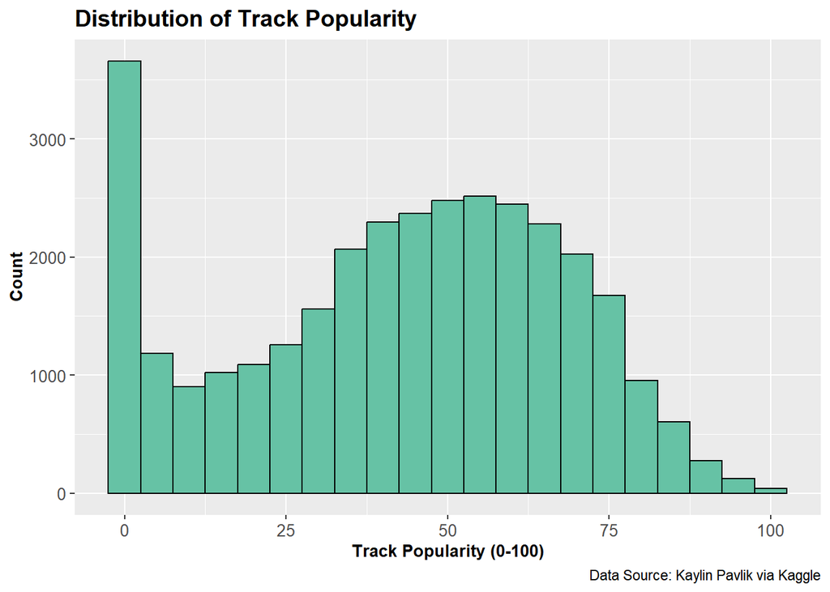

Figure 1: Distribution of the target variable, track popularity

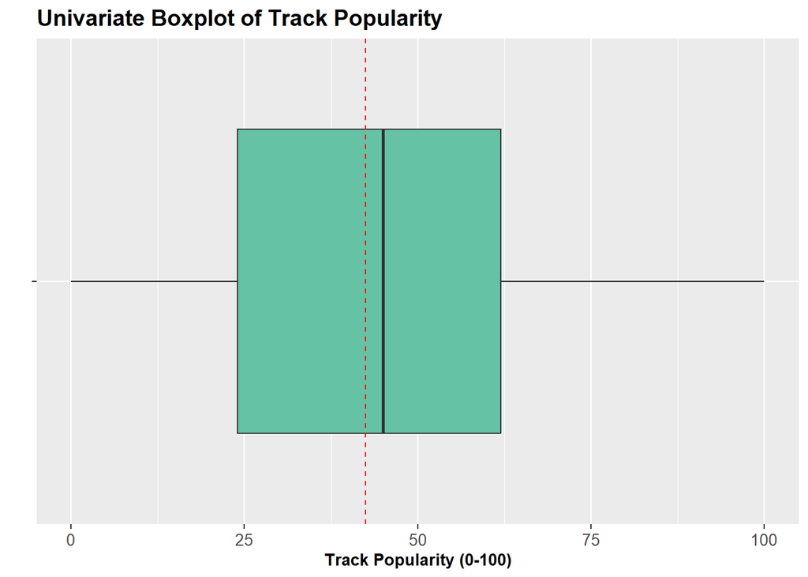

Figure 2: Boxplot of the target variable, track popularity

The distribution of track popularity is bi-modal, with one mode at 0 and the other at ~55-60; the range of the distribution is 100 (see Figure 1). The box plot (Figure 2) indicates that the mean and median are close together and between 40 and 45; these are fairly close to the center of the range (50), indicating minimal left skew. There are no apparent outliers. Stratified sampling to ensure that the 0-value observations are equally incorporated according to their proportionality will be necessary to accommodate the bi-modality.

### Predictor Variables

13 variables from the data have been selected as predictors for this analysis:

**Categorical variables:**

- `playlist_genre`: the broad genre of the track - rap, pop, r&b, edm, rock or Latin.
- `key`: the key in which the track is written.
- `mode`: the mode, or type of key, the song is written in (major or minor).

**Continuous variables:**

- `danceability`: how danceable is the song?
- `energy`: how energetic is the song?
- `loudness`: how loud, on average, is the song?
- `speechiness`: how much spoken word material does the song contain?
- `acousticness`: a confidence measure of whether or not the song is acoustic.
- `instrumentalness`: a confidence measure of whether or not the song contains sung lyrics.
- `liveness`: a confidence measure of whether or not the song was recorded during a live performance.
- `valence`: how positive in nature is the song?
- `tempo`: how slow or fast is the song?
- `duration_ms`: how long, in milliseconds, is the song?

See Section 8 for more details on the distributions, properties and transformations of the predictor variables.

## **Methods**

**Assessing the problem**

The problem analyzed in this project is a regression problem. The competing models will be assessed using root mean squared error (RMSE).

**Setting a seed for random processes**

A seed was set to ensure replication of all random processes in the modelling process. This was done using the following code: `set.seed(5)`

The first step in the analysis process was splitting the cleaned dataset and constructing a set of resamples. The `initial_split` function was used to split the full data set into a training set for model training and a testing set for use with the final selected model - this was an 80% training/20% testing split with stratification for track popularity. The set of resamples was constructed using 10-fold cross validation repeated five times, with stratification for track popularity.

A brief EDA was conducted on the training dataset to examine the distributions of predictor variables and the need for transformations (please see Section 8). Due to the irregular shape of the distributions of some of the numeric predictor variables, three different recipes for modeling were compared to see which type of transformations yielded the best results; this comparison was done using the chosen assessment metric of RMSE. The three different recipes adopted different approaches to the irregularly distributed numeric variables: 1) no transformation; 2) logarithmic and exponential transformations; 3) natural splines transformations. It was found that the simple recipe which did not transform the numeric variables yielded the best RMSE metrics across the models.

The following models and parameters were then initialized:

- **null model**, with engine `parsnip` (for use as a baseline)
- **linear regression model**, with engine `lm` and no parameters tuned
- **elastic net model**, with engine `glmnet`
  - `penalty` tuned over $[-1,0]$ with 10 levels
  - `mixture` tuned over $[0,1]$ with 10 levels
- **k-nearest neighbors model**, with engine `kknn`
  - `neighbors` tuned over $[1,15]$ with 10 levels
- **random forest tree model**, with engine `ranger`
  - `trees` set to 1000
  - number of randomly selected predictors to split (`mtry`) on tuned over $[1,13]$ with 5 levels
  - minimum number of data points in a node for splitting (`min_n`) tuned over $[2,40]$ with 5 levels
- **boosted tree model**, with engine `xgboost`
  - `trees` set to 1000
  - number of randomly selected predictors to split (`mtry`) on tuned over $[1,13]$ with 3 levels
  - minimum number of data points in a node for splitting (`min_n`) tuned over $[2,40]$ with 3 levels
  - learning rate (`learn_rate`) tuned over $[-5,-0.2]$ with 3 levels

## **Model Building & Selection**

**Assessing the problem**

The problem analyzed in this project is a regression problem. The competing models will be assessed using root mean squared error (RMSE).

The above models and tuning grids were trained and examined using the cross-validations folds resamples set. As mentioned above, the recipe that yielded the lowest RMSE values across the models was the “simple” recipe that did *not* transform numeric variables, and simply dummy-coded factor variables, created an interaction term between song duration and genre (non-tree models only), normalized all variables and filtered out variables with zero variance.

### Model Training Results

Overall, the tuning process was especially useful for the tree-based models, as maximizing the number of randomly selected predictor variables (`mtry`) and minimizing the minimum number of data points in a node for splitting (`min_n`) was very important to yielding lower RMSE scores. Elsewhere, maximizing the number of neighbors for the k-nearest neighbors was important to reducing its error.

The following were the best RMSE values for each trained model, and the tuned hyper-parameters that yielded these RMSE values.

Table 1: Best mean RMSE values by trained model type

| Model Type | Mean RMSE | Standard Error | Number of Models |
| --- | --- | --- | --- |
| Null | 24.96830 | 0.0207470 | 50 |
| Linear Reg. | 23.80316 | 0.0248700 | 50 |
| Elastic Net | 23.80322 | 0.0247175 | 50 |
| K-Nearest Neighbors | 24.44539 | 0.0289151 | 50 |
| Random Forest Tree | 21.38259 | 0.0266924 | 50 |
| Boosted Tree | 23.44281 | 0.0249668 | 50 |

*Corresponding Hyper-parameters (See Table 1):*

- **Null:** no tuned parameters.
- **Linear Reg.:** no tuned parameters.
- **Elastic Net:** `penalty` = 0.1 || `mixture` = 0.111
- **K-Nearest Neighbors:** `neighbors` = 15
- **Random Forest Tree:** `mtry` = 13 || `min_n` = 2
- **Boosted Tree:** `mtry` = 13 || `min_n` = 2 || `learn_rate` = 0.00251

As shown in Table 1, the models overall had best mean RMSE value between 21.38 and 24.97. These mean RMSE values were generated by averaging the RMSE of the 50 models fit using the resamples set and the above hyper-parameters per model type. The range suggests that the models trained all predict Spotify track popularity with a mean error of 21-25 points on the un-transformed track popularity scale of 0-100 using the input recipe and predictor variables. In taking the null model as the baseline, every other model beat it in that they all had lower best mean RMSE values; out of the five non-baseline models, the k-nearest neighbors model had the highest degree of error. The best performing model was the random forest tree model with the above parameters, as it had the lowest RMSE value of 21.38; this means it was, on average, the most accurate in predicting the track popularity scores of the songs in the training dataset.

## **Final Analysis**

As mentioned above, the best performing model is the random forest tree model with 13 randomly selected variables and a node-splitting minimum of two. This is the model that was first trained on the entire, unfolded training dataset and then tested on the testing dataset to generate predictions and test the performance of the model.

### Testing Results

Table 2: Final tested model metrics

| Metric | Estimate |
| --- | --- |
| rmse | 21.15905 |
| rsq | 0.28752 |

See Table 2. The RMSE value of the final model applied to the testing set is 21.16. This means that, on average, the final model’s predictions were 21.16 track popularity points away from the true track popularity values in the testing dataset. Given that track popularity is measured on a scale of 0-100, this is a fairly high magnitude of error and suggests that track popularity cannot be easily predicted using the musical attributes of a song. This is supported by the R-squared value of 0.2875, which means that 28.75% of the variation in track popularity is explained by variation in the predictor variables (the track’s musical attributes).

Furthermore, when put in context with the null model as the baseline, the tuned random forest model had an RMSE of only ~3.8 points lower than the null model, which is a relatively small difference given that the target variable is measured on a scale of 0-100. This indicates that more advanced problems do not necessarily lead to significantly improved predictions of track popularity. Overall, this and the above points suggest that track popularity does not correlate with its own musical attributes, and might instead be explained by either variables not measured in the dataset or variables external to the song (the social/political context in which it was released, its lyrical content, etc.)

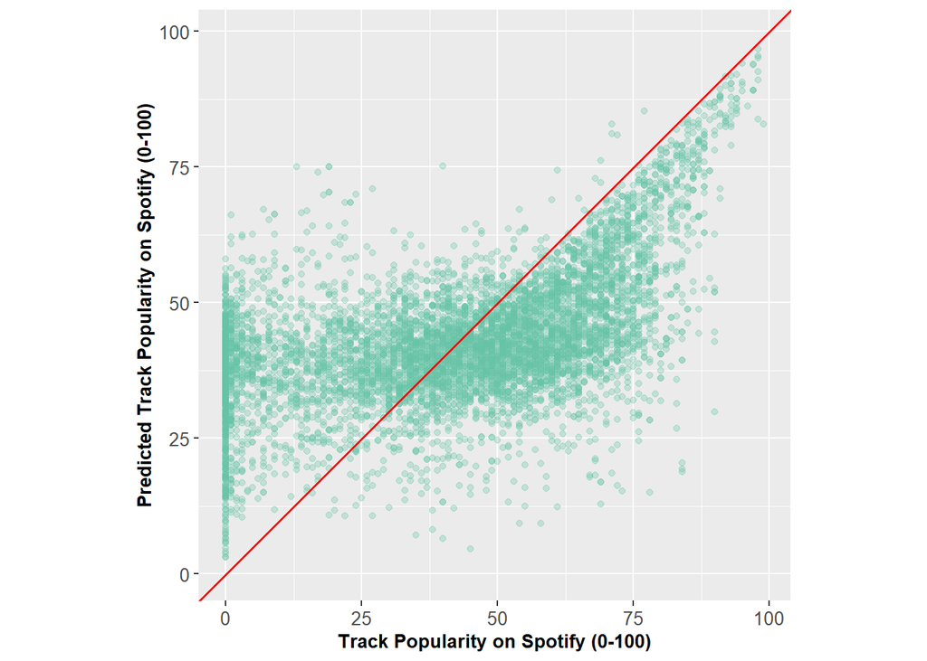

Figure 3: Plot of observed track popularity scores by predicted track popularity scores

Figure 3 supports the above conclusions by showing how, for tracks with a track popularity score lower than 75, there is little-to-no correlation between actual track popularity scores and track popularity scores predicted by the final model. There is an especially wide range of predicted values (y-values) for tracks that have a popularity score of 0, which suggests that the final model had the most difficulty predicting the popularity of songs that are actually not popular on Spotify. Elsewhere, there is a stronger positive correlation between actual track popularity and predicted track popularity in the range of 75-100 popularity.

This suggests that the model could predict the popularity of the most popular tracks in the testing dataset with less error than less popular tracks in the dataset. This builds on the point laid out above in that a song’s musical attributes might only correlate with its streaming popularity in the cases of the most popular songs. However, because there is little correlation between the predictors and the target variable for songs with a popularity less than ~70 (ie. the supermajority of songs), this suggests that a song’s musical attributes are weak predictors of its streaming popularity and instead variables outside of a song’s attributes (and outside the dataset) might be stronger predictors.

## **Conclusion**

This study used predictive modeling and a dataset of songs from Spotify’s streaming database to examine whether a song’s streaming popularity can be predicted by its musical attributes, such as tempo, key, genre, etc. It was found that a song’s musical attributes are not strong predictors of its popularity, especially for less popular songs; measuring track popularity on a scale of 0-100, the final tested model, on average, predicted track popularity scores with a magnitude of error of 21.16 points on this scale.

If certain musical characteristics cannot indicate a popular song, this firstly raises the question: can track popularity be predicted? If it can be predicted, further research should be directed to an examination of variables external to the song itself, such as the sociopolitical context of a song’s release or its lyrical content. As such, next steps could apply a similar modeling procedure as used in this lab on data measuring track popularity alongside variables like lyric keywords and the interaction between a song’s date of release and its country of origin.

## **References**

**Project Data**

Pavlik, Kaylin, “30000 Spotify Songs.” CSV File, Data set, 2019. https://www.kaggle.com/datasets/joebeachcapital/30000-spotify-songs/data.

[Dataset Link](https://www.kaggle.com/datasets/joebeachcapital/30000-spotify-songs/data)

## **Technical Info and EDA**

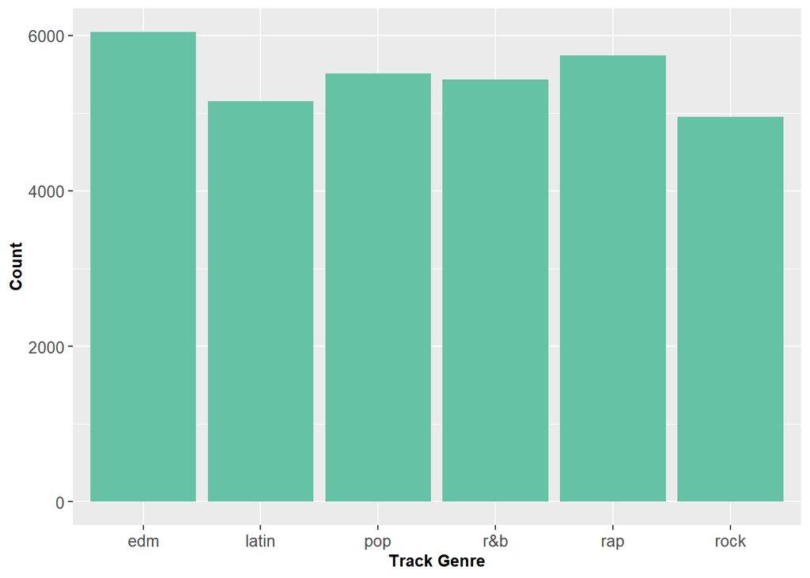

Figure 4: Distribution of track genre

See Figure 4. The categorical variable track genre has six values (levels): EDM, Latin, pop, R&B, rap and rock. The distribution of track genre is approximately uniform, with the difference between two values being no more than ~1000 songs.

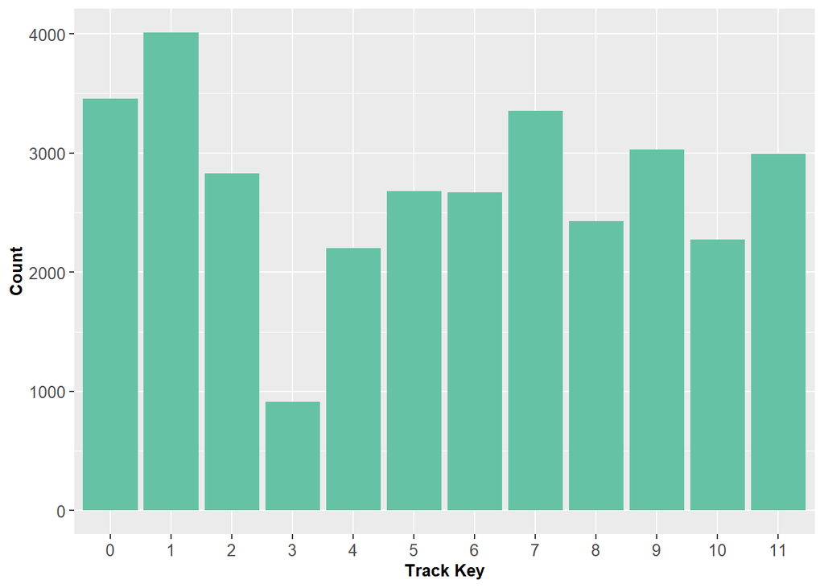

Figure 5: Distribution of track key

See Figure 5. The categorical variable of track key has 12 values, with each number corresponding to a key as per musical notation, where 0 is the key of C and 11 is the key of B. The distribution of the variable is less uniform than track genre, with value 3 (D#/Eb) having notably fewer observations than the others. However, because the difference between other values is still around ~1000-1500 songs, no transformation is needed.

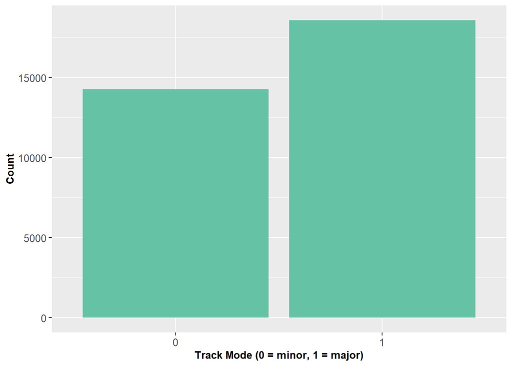

Figure 6: Distribution of track mode

**Distributions and tested transformations of continuous variables**:

- `danceability`: approximately normal distribution || no transformation
- `energy`: approximately normal distribution || no transformation
- `loudness`: skewed left distribution || logarithmic (base 10) transformation (alternate recipe 1); natural splines transformation with 100 degrees of freedom (alternate recipe 2)
- `speechiness`: heavily skewed right distribution || logarithmic (base 10) transformation (alternate recipe 1); natural splines transformation with 100 degrees of freedom (alternate recipe 2)
- `acousticness`: skewed right distribution || cubic root transformation (alternate recipe 1)
- `instrumentalness`: uni-modal with small degree of skew || no transformation
- `liveness`: skewed right distribution || cubic root transformation (alternate recipe 1); natural splines transformation with 100 degrees of freedom (alternate recipe 2)
- `valence`: approximately normal distribution || no transformation
- `tempo`: bi-modal, approximately symmetric distribution || no transformation
- `duration_ms`: approximately normal distribution || no transformation